# Supervised Learning - Classification 01

## **Pendahuluan Data Mining**

### **https://taudata.blogspot.com/p/applied-data-mining-adm.html**

[figure not shown]

## **Supervised Learning - Classification 01**

### **https://taudata.blogspot.com/2020/04/slcm-01.html**

# **Notes and Disclaimer**

- This notebook is part of the free (open knowledge) eLearning course at: https://taudata.blogspot.com/
- Some images are taken from several resources, we respect those images ownerships and put a reference/citation from where it is originated. Nevertheless, sometimes we are having trouble to find the origin of the image(s). If you are the owner of the image and would like the image taken-out (or want the citation to be revised) from this open knowledge course resources please contact us with the details.
- Unless stated otherwise, in general tau-data permit its resources to be copied and-or modified for non-commercial purposes. With condition proper acknowledgement/citation is given.

# Outline Module:

- Pengantar ke Predictive Modelling
- Regresi Logistik
- Metrics Evaluasi dan Cross Validasi
- Confusion Matrix
- k-Nearest Neighbour
- Decision Tree
- Naive Bayes Classifier

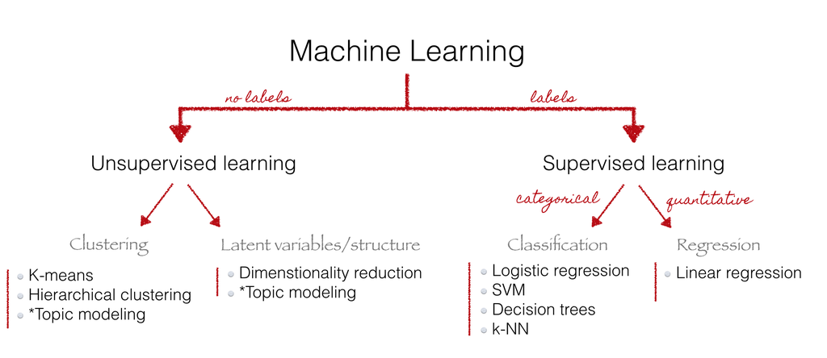

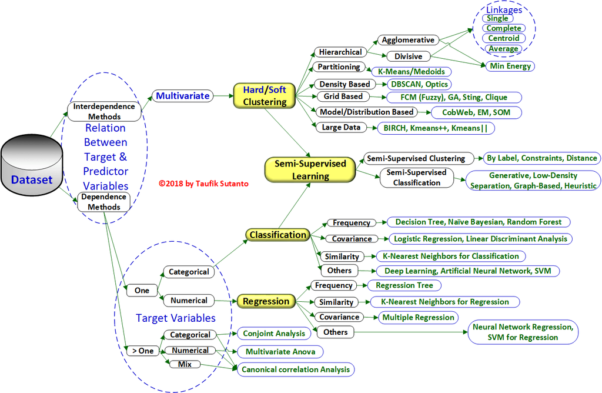

# Pendahuluan Klasifikasi

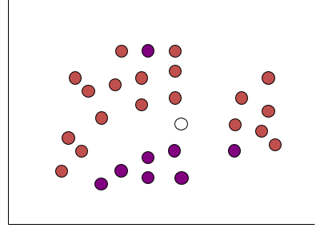

- Misal diberikan permasalahan terdapat dua buah kategori orange dan ungu seperti di gambar.
- Setiap titik di ganmbar adalah entitas dari data yang terdiri dari beberapa variabel.
- Jika diberikan titik baru (warna putih), maka masalah klasifikkasi adalah kemudian menggolongkan data baru ini ke kategori titik Orange atau Ungu.

# Klasifikasi dengan Model Regresi Logistik

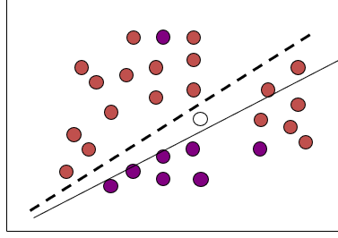

- Mencari garis lurus yang sedemikian sehingga kesalahan prediksinya sekecil mungkin (lihat gambar)

# Regresi Logistik

- Awalnya regresi logistik adalah metode klasifikasi binary: membedakan antara 2 kelas atau kategori.
- Masalah klasifikasi binary contohnya memprediksi seseorang terkena "kanker" atau "tidak kanker", kanker jinak/ganas, fraud atau bukan fraud (pada transaksi keuangan), negatif/positif dalam sentimen analisis, dsb.
- Regresi logistik adalah pengembangan dari model regresi liniear, namun di konversi ke masalah klasifikasi.

## Regresi Logistik

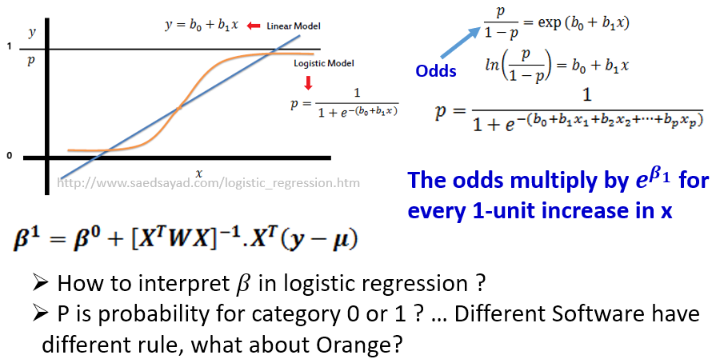

- http://www.saedsayad.com/logistic_regression.htm
- Makna fungsi logarithm?
- Konsekuensi dari rumus $\beta$ diatas?
- Asumsi?

# Kaitan Regresi Logistik dan Neural Network/Deep Learning

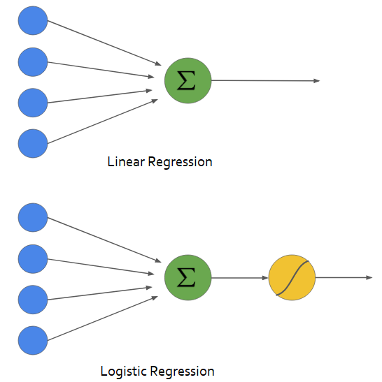

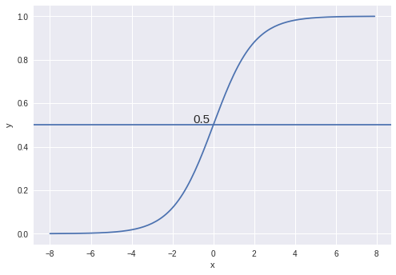

## Logistic Linear Regression

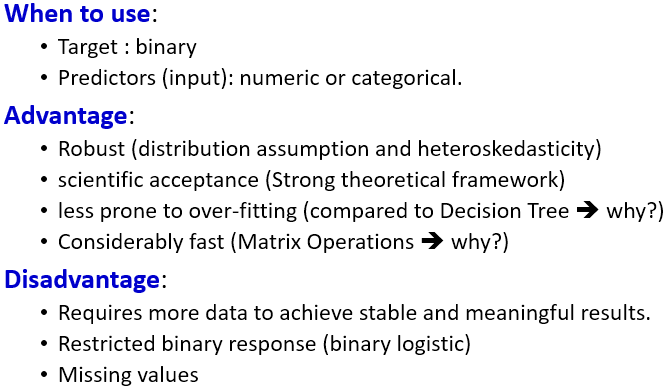

# Over Fitting?

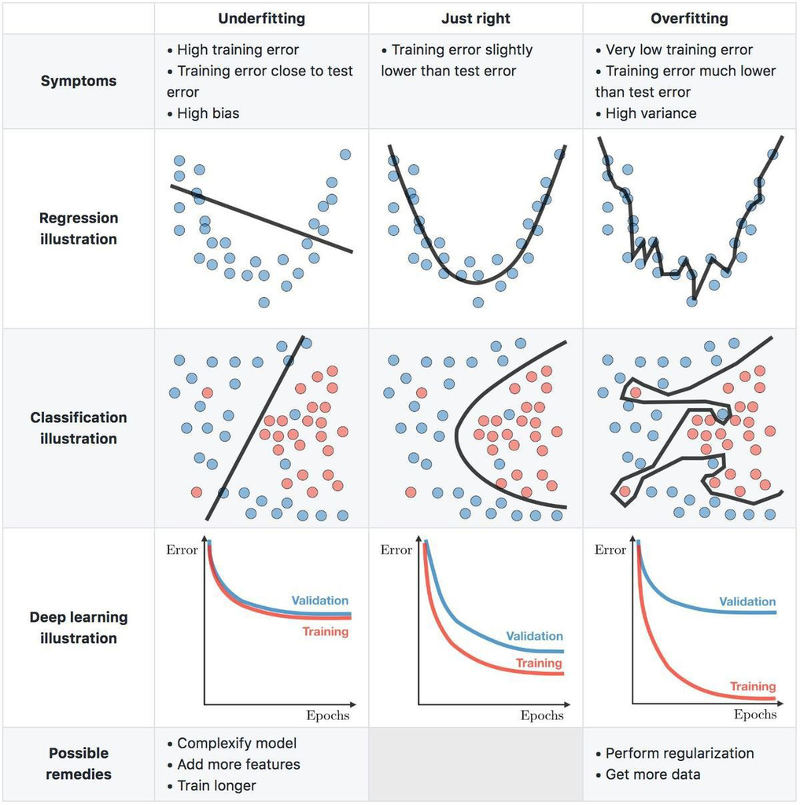

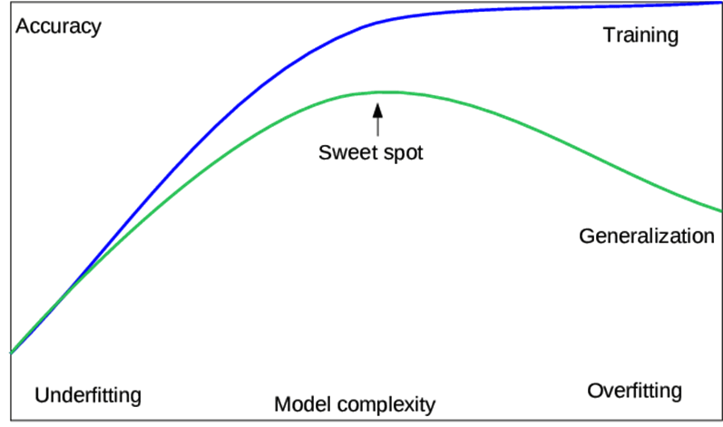

## Regularization

- Misal $\beta$ ==> $w$
- Di perumusan regresi logistik awal, ada kemungkinan beta akan selalu positif dan besar (walau mungkin variabelnya kurang/tidak signifikan menerangkan variabel target ~ y).
- Untuk mencegah hal ini (~over fitting), model supervised learning (klasifikasi) menggunakan teknik regulerisasi.
- Konsep Regularisasi tidak hanya digunakan dalam regresi logistik, namun juga model lain seperti SVM, JST, Deep Learning, dll.
- Memahami konsep ini akan sangat bermanfaat di Data Science.
- Misal E(w) adalah fungsi error/loss function yang sudah kita sebelumnya dan $t_n$ adalah nilai sesungguhnya, maka regulerisasi dilakukan dengan mengoptimalkan fungsi berikut ini:

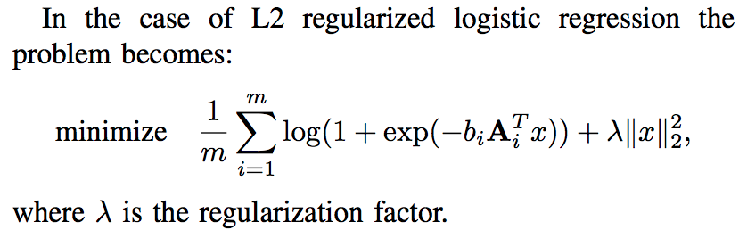

# Diskusi

- Regresi Logistik tidak dapat mengolah data yang mengandung "missing values"/null, mengapa?
- Jika kita merubah persamaannya (misal dengan mencoba berbagai transformasi variabel) sedemikian sehingga didapatkan model yang sedikit lebih baik (akurasinya) dibandingkan model yang lebih sederhana, apakah kita akan menggunakan model tersebut? Mengapa?
- Seperti regresi linear, apakah kita perlu standarisasi/scaling data?